# COVID-19 Cases

## Introduction

The following analysis is taking the US / Global Cases of COVID19 and using the data to draw some insights of the data. Throughout this analysis we are curious on understanding these cases throughout the last couple years to provide context and to help identify patterns within the data that could help provide legislators or health professionals the opportunity to make changes. Much of the work was done by following what Dr Wall has done for us. So in addition to the questions Dr Wall asked, how does the cases / 1000 differ between States? We will be focusing on Tennessee and New York as an interesting comparison between the states.

## Importing data

First course of action is to import the data necessary for this analysis. The data in this analysis comes from the [John Hopkins Github](https://github.com/CSSEGISandData/COVID-19/tree/master/csse_covid_19_data/csse_covid_19_time_series) site which holds daily numbers from across the globe on COVID. Much of the data include details down to the county in later months of the pandemic.

```r
link <- "https://github.com/CSSEGISandData/COVID-19/raw/master/csse_covid_19_data/csse_covid_19_time_series/"

files <- c("time_series_covid19_confirmed_US.csv", "time_series_covid19_confirmed_global.csv", "time_series_covid19_deaths_US.csv", "time_series_covid19_deaths_global.csv", "time_series_covid19_recovered_global.csv")

US_cases <- read_csv(paste0(link,files[1]))
global_cases <- read_csv(paste0(link,files[2]))
US_deaths <-  read_csv(paste0(link,files[3]))
global_deaths <- read_csv(paste0(link,files[4]))
# covid_data <- read_csv(link)

uid_lookup_url <- "https://raw.githubusercontent.com/CSSEGISandData/COVID-19/master/csse_covid_19_data/UID_ISO_FIPS_LookUp_Table.csv"
uid <- read_csv(uid_lookup_url)
```

## Data Processing

Currently there are 5 files that contain all of the information that we need in order to do the proper analysis of the data. Therefore we are going to use a number of techniques to meld the data into a version that we can analyze.

### Cleaning / Joining Global Cases

Taking the global cases, we have a number of columns that we are not going to be using in the analysis.

#### Pro-Tip on large datasets

One think to remember when working with larger datasets, the data is loaded into memory. Thus when you have 8 GB of memory and 9 gb of data, R is going to crash and will nto be able to perform the analysis. Therefore it is good to get into habit of considering it.

```r
global_cases  <- global_cases %>% pivot_longer(cols = -c(`Province/State`, `Country/Region`, Lat, Long), names_to = "date", values_to = "cases") %>% select(-c(Lat, Long))

global_deaths  <- global_deaths %>% pivot_longer(cols = -c(`Province/State`, `Country/Region`, Lat, Long), names_to = "date", values_to = "deaths") %>% select(-c(Lat, Long))

global <- global_cases %>%
  full_join(global_deaths) %>%
  rename(Country_Region = `Country/Region`, Province_State = `Province/State`) %>%
  mutate(date = mdy(date))
```

### Cleaning / Joining US Cases

Again we are going to do the same process as above, however just for the US data.

```r
US_cases <- US_cases %>% pivot_longer(cols = -(UID:Combined_Key),
                          names_to = "date",
                          values_to = "cases") %>%
  select(Admin2:cases) %>% mutate(date = mdy(date)) %>%
  select(-c(Lat, Long_))

US_deaths <- US_deaths %>%
  pivot_longer(cols = -(UID:Population),
               names_to = "date",
               values_to = "deaths") %>%
  select(Admin2:deaths) %>%
  mutate(date = mdy(date)) %>%
  select(-c(Lat, Long_))

US <- US_cases %>% full_join(US_deaths)
```

### Join Global and US Cases

```r
global <- global %>% unite("Combined_Key",
                           c(Province_State, Country_Region),
                           sep = ", ",
                           na.rm = TRUE,
                           remove = FALSE)
```

One thing that is missing from the Global dataset is population. Therefore to add population to the global dataset we need to find the data (can see the import above) and then join the two datasets together.

```r
uid <- uid %>% select(-c(Lat, Long_, Combined_Key, code3, iso2, iso3, Admin2))
global <- global %>% left_join(uid, by = c("Province_State", "Country_Region")) %>%
  select(-c(UID, FIPS)) %>%
  select(Province_State, Country_Region, date, cases, deaths, Population, Combined_Key)
```

Now that all of the information is in one dataset, we can now start asking questions of the data.

```r
head(global)
```

| Province_State | Country_Region | date | cases | deaths | Population | Combined_Key |
| --- | --- | --- | --- | --- | --- | --- |
| NA | Afghanistan | 2020-01-22 | 0 | 0 | 38928341 | Afghanistan |
| NA | Afghanistan | 2020-01-23 | 0 | 0 | 38928341 | Afghanistan |
| NA | Afghanistan | 2020-01-24 | 0 | 0 | 38928341 | Afghanistan |
| NA | Afghanistan | 2020-01-25 | 0 | 0 | 38928341 | Afghanistan |
| NA | Afghanistan | 2020-01-26 | 0 | 0 | 38928341 | Afghanistan |
| NA | Afghanistan | 2020-01-27 | 0 | 0 | 38928341 | Afghanistan |

## Data Analysis

### How can we measure the rate of death between US and US States?

First we need to create a new variable that will give us a rate in order for us to better understand death rates by the US as a whole and states

```r
US_by_state <- US %>%
  group_by(Province_State, Country_Region, date) %>%
  summarize(cases = sum(cases), deaths = sum(deaths), Population = sum(Population)) %>%
  mutate(deaths_per_mill = deaths * 1000000 / Population) %>%
  select(Province_State, Country_Region, date, cases, deaths, deaths_per_mill, Population) %>%
  ungroup()
US_totals <- US_by_state %>%
  group_by(Country_Region, date ) %>%
  summarize(cases = sum(cases), deaths = sum(deaths),
            Population = sum(Population)) %>%
  mutate(deaths_per_mill = deaths * 1000000 / Population) %>%
  select(Country_Region, date, cases, deaths, deaths_per_mill, Population) %>%
  ungroup()
```

### Visualizing COVID cases in the US

First we wanted to see how the cumulative cases stack up to the deaths of COVID in the US. This gives us a LOG graph of the data rendering the information to create an almost straight line due to the compressing nature of a log graph.

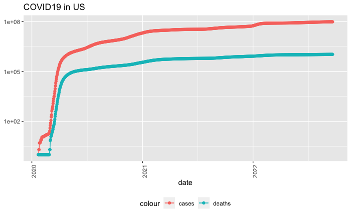

```r
US_totals %>% filter(cases > 0) %>%
  ggplot(aes(x = date, y = cases)) +
  geom_line(aes(color = "cases")) +
  geom_point(aes(color = "cases")) +
  geom_line(aes(y = deaths, color = "deaths")) +
  geom_point(aes(y = deaths, color = "deaths")) +
  scale_y_log10() +
  theme(legend.position = "bottom",
        axis.text.x = element_text(angle = 90)) +
  labs(title = "COVID19 in US", y = NULL)
```

### Visualizing COVID cases on a particular state

Now we create another graph of the same analysis as we had on the US data, but this time we will look at the state of Tennessee. Again we see that past 2022, the data is compressed that it gives us a flat line and is would be probably difficult to draw any insight from the data.

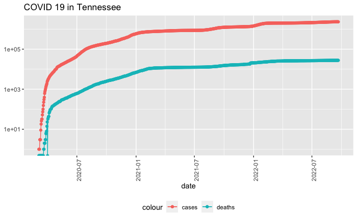

```r
state <- "Tennessee"
US_by_state %>%
  filter(Province_State == state) %>%
  filter(cases > 0 ) %>%
  ggplot(aes(x = date, y = cases)) +
  geom_line(aes(color="cases")) +
  geom_point(aes(color="cases")) +
  geom_line(aes(y =deaths, color = "deaths")) +
  geom_point(aes(y = deaths, color = "deaths")) +
  scale_y_log10() +
  theme(legend.position = "bottom",
        axis.text.x = element_text(angle = 90)) +
  labs(title=str_c("COVID 19 in ", state), y = NULL)
```

Above we observed the cumulative cases day to day, as the magnitude grew, as we see in the above graphs it what does it look like when we only observe the new cases day to day. We need to add a few more details to our dataset in order to further analyze.

```r
US_by_state <- US_by_state %>%
  mutate(new_cases = cases - lag(cases),
         new_deaths = deaths - lag(deaths))

US_totals <- US_totals %>%
  mutate(new_cases = cases - lag(cases),
         new_deaths = deaths - lag(deaths))
```

We have added two columns `new_cases` and `new_deaths` to give us a better understanding of the new cases by day.

```r
tail(US_totals %>% select(new_cases, new_deaths, everything()))
```

| new_cases | new_deaths | Country_Region | date | cases | deaths | deaths_per_mill | Population |
| --- | --- | --- | --- | --- | --- | --- | --- |
| 59018 | 423 | US | 2022-09-16 | 95656684 | 1053435 | 3164.655 | 332875137 |
| 8314 | 23 | US | 2022-09-17 | 95664998 | 1053458 | 3164.724 | 332875137 |
| 4710 | 7 | US | 2022-09-18 | 95669708 | 1053465 | 3164.745 | 332875137 |
| 53789 | 380 | US | 2022-09-19 | 95723497 | 1053845 | 3165.887 | 332875137 |
| 52812 | 421 | US | 2022-09-20 | 95776309 | 1054266 | 3167.152 | 332875137 |
| 98282 | 929 | US | 2022-09-21 | 95874591 | 1055195 | 3169.942 | 332875137 |

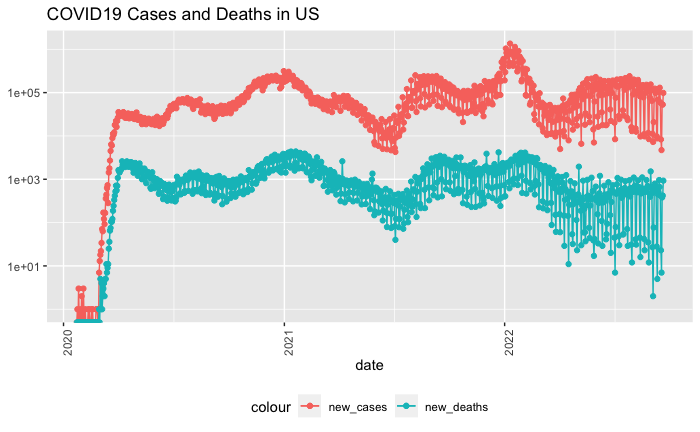

```r
US_totals %>%
  ggplot(aes(x=date, y=new_cases)) +
  geom_line(aes(color="new_cases")) +
  geom_point(aes(color="new_cases")) +
  geom_line(aes(y=new_deaths, color="new_deaths")) +
  geom_point(aes(y = new_deaths, color = "new_deaths")) +
  scale_y_log10() +
  theme(legend.position = "bottom",
        axis.text.x = element_text(angle=90))+
  labs(title="COVID19 Cases and Deaths in US", y = NULL)
```

- Mortality rate of COVID-19 variant not as “successful”
- Herd immunity according to some news platforms
- Inconsistent data collection between states and centers (though this is going to have a margin of error)

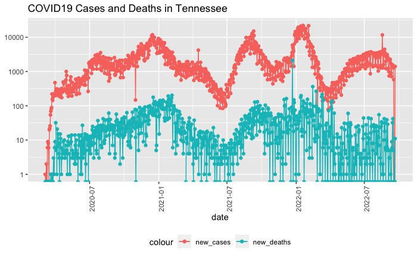

```r
state <- "Tennessee"
US_by_state %>%
  filter(cases > 0) %>%
filter(Province_State == state) %>%
  ggplot(aes(x = date, y = new_cases)) +
  geom_line(aes(color = "new_cases")) +
  geom_point(aes(color = "new_cases")) +
  geom_line(aes(y = new_deaths, color = "new_deaths")) +
  geom_point(aes(y = new_deaths, color = "new_deaths")) +
  scale_y_log10() +
  theme(legend.position  = "bottom",
        axis.text.x = element_text(angle = 90)) +
  labs(title=str_c("COVID19 Cases and Deaths in ", state), y = NULL)
```

The following is an interesting trend that keeps oscillating due to the “less strict” policies in TN. However there isn’t much to be compared to here. Let’s take NY and TN for example as a case and point.

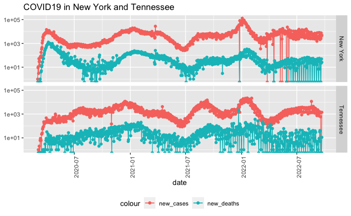

```r
state <- c("Tennessee","New York")
US_by_state %>%
  filter(cases > 0) %>%
filter(Province_State %in% state) %>%
  ggplot(aes(x = date, y = new_cases)) +
  geom_line(aes(color = "new_cases")) +
  geom_point(aes(color = "new_cases")) +
  geom_line(aes(y = new_deaths, color = "new_deaths")) +
  geom_point(aes(y = new_deaths, color = "new_deaths")) +
  facet_grid("Province_State~.") +
  scale_y_log10() +
  theme(legend.position  = "bottom",
        axis.text.x = element_text(angle = 90)) +
  labs(title=str_c("COVID19 in ", state[2], " and ", state[1]), y = NULL)
```

There is definitely some usefulness when observing the data like so… We see that the September 2021 upswing in cases was higher… but really to make the data comparable we need to look at the information from a per 1000 incidence in order to understand what might be going on with the data.

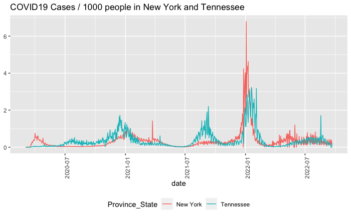

```r
state <- c("Tennessee","New York")
US_by_state %>%
   filter(cases > 0 & Province_State %in% state) %>%
  mutate( cases_per_thou = 1000*new_cases/Population,
          deaths_per_thou = 1000*new_deaths/Population) %>%
  ggplot(aes(x = date, y = cases_per_thou, color = Province_State)) +
  geom_line(aes()) +
  theme(legend.position  = "bottom",
        axis.text.x = element_text(angle = 90)) +
  labs(title=str_c("COVID19 Cases / 1000 people in ", state[2], " and ", state[1]), y = NULL)
```

This is actually a fascinating story to look at, in this graph. We see that New York started out the pandemic with a much high rate than TN due to it being ground 0 for COVID and a central hub with a much higher contact factor (essentially the number of people one might have contact with in a day).

But the cycle of the first wave of COVID started subsiding due to the lockdowns within the first 5 months of the year.

We see a rise start in August (when school begins in TN) and we see that it seems to hover pretty consistently till the holidays and has a spike in Nov / Dec and drops off. Look at the rates at which those drop offs occur… we see TN have a significant spike and drop off, but in NY we see that the drop off is extended. This is most likely due to the masking mandates, homeschool and lockdowns. This provides some insight into how for health care workers the hospital resources would not be overwhelmed but rather find themselves able to manage and provide better care for the sick.

Up until the school year of 2021, we have an identical spike in TN as we had previously with the same tapering off of cases… but almost no increase until the holidays of 2021 where we see a much larger spike in NY then we had seen in TN.

There are a number of reasons for that… the delta started started becoming the predominant strain in Nov 2021 and it was known to be more contagious. So we see a much high case load but it wouldn’t surprise me in the least that there was some COVID fatigue going on as well and people were more willing to take the risk as it wasn’t an unknown disease at this point anymore.

This analysis is definitely a viewpoint that would need much more verification.

### What about the rate of deaths between TN and NY?

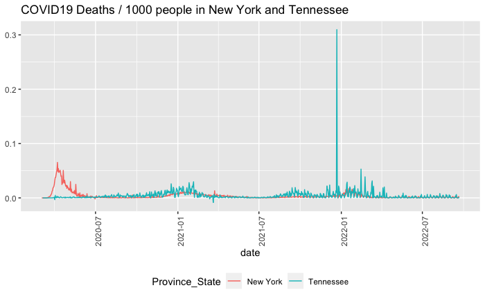

```r
state <- c("Tennessee","New York")
US_by_state %>%
   filter(cases > 0 & Province_State %in% state) %>%
  mutate( cases_per_thou = 1000*new_cases/Population,
          deaths_per_thou = 1000*new_deaths/Population) %>%
  ggplot(aes(x = date, y = deaths_per_thou, color = Province_State)) +
  geom_line(aes()) +
  theme(legend.position  = "bottom",
        axis.text.x = element_text(angle = 90)) +
  labs(title=str_c("COVID19 Deaths / 1000 people in ", state[2], " and ", state[1]), y = NULL)
```

Interesting enough, we see the .3 see the rate at the end of 2021 skyrocket making it difficult to simply visulaize the data. This could have been a correction where data hadn’t been kept in earlier days due to holiday backlog. So just for the sake of clarity, lets see what it looks like if we were to take the outlier out.

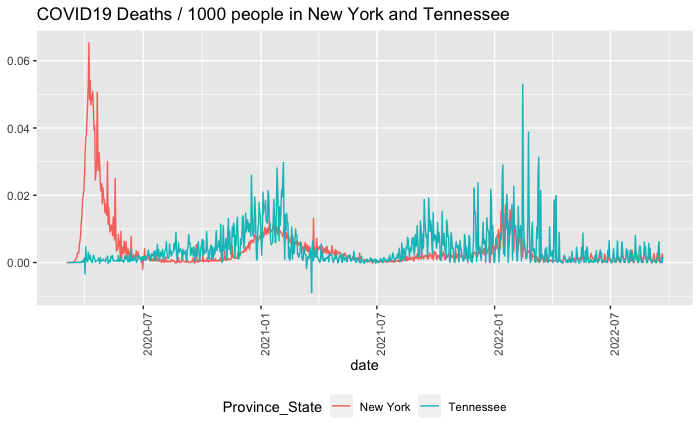

```r
state <- c("Tennessee","New York")
US_by_state %>%
   filter(cases > 0 & Province_State %in% state) %>%
  mutate( cases_per_thou = 1000*new_cases/Population,
          deaths_per_thou = 1000*new_deaths/Population) %>%
  filter(deaths_per_thou < 0.1) %>%
  ggplot(aes(x = date, y = deaths_per_thou, color = Province_State)) +
  geom_line(aes()) +
  theme(legend.position  = "bottom",
        axis.text.x = element_text(angle = 90)) +
  labs(title=str_c("COVID19 Deaths / 1000 people in ", state[2], " and ", state[1]), y = NULL)
```

Outside of the first spike in NY, we see that TN though alot of spikes, we could smoothen out the data and we’d find that the rate is for the majority of the last 2.5 years are higher in TN then they are in NY. The scale here might seem small.. but even at 0.04 per 1000 is 4 people per 100,000 or 40 people per million can be quite telling as that rate never even came close in NY.

## How do we compare data between countries or states?

```r
US_state_totals <- US_by_state %>%
group_by(Province_State) %>%
summarize(deaths = max(deaths), cases=max(cases),
          population=max(Population),
          cases_per_thou = 1000*cases/population,
          deaths_per_thou = 1000*deaths/population) %>%
  filter(cases > 0, population > 0)
```

After summarizing the data by state, we can start comparing the worst day throughout the entire 2.5 years that COVID has been around. We see that for the 10 lowest states:

```r
US_state_totals %>% slice_min(deaths_per_thou,n = 10)%>% select(deaths_per_thou, cases_per_thou, everything())
```

| deaths_per_thou | cases_per_thou | Province_State | deaths | cases | population |
| --- | --- | --- | --- | --- | --- |
| 0.6110602 | 147.6789 | American Samoa | 34 | 8217 | 55641 |
| 0.7253736 | 238.7567 | Northern Mariana Islands | 40 | 13166 | 55144 |
| 1.1466607 | 215.3019 | Virgin Islands | 123 | 23095 | 107268 |
| 1.1522639 | 227.3117 | Vermont | 719 | 141840 | 623989 |
| 1.1858417 | 242.3976 | Hawaii | 1679 | 343204 | 1415872 |
| 1.3542164 | 252.4957 | Puerto Rico | 5085 | 948106 | 3754939 |
| 1.5599081 | 322.7166 | Utah | 5001 | 1034616 | 3205958 |
| 1.8407682 | 401.5709 | Alaska | 1364 | 297562 | 740995 |
| 1.8706763 | 237.1381 | Washington | 14245 | 1805781 | 7614893 |
| 1.9111569 | 213.7185 | Maine | 2569 | 287283 | 1344212 |

And then the 10 highest states with a bunch of those states being in the in the southern states. This can be due to again a few different things.

- legislative policies - the north in general was much stricter in masking mandates and lockdown initiatives.
- health - there could be a case made that the southern states is more obese than some of the other states
- Population demographics - Age of the population could also cause this data to be higher in the southern states than in the northern states.

All these reasons could be due to a number of things but without external data and confirmation it would be difficult to know for certain if there is any validity in reasonings given.

```r
US_state_totals %>% slice_max(deaths_per_thou,n = 10)%>% select(deaths_per_thou, cases_per_thou, everything())
```

| deaths_per_thou | cases_per_thou | Province_State | deaths | cases | population |
| --- | --- | --- | --- | --- | --- |
| 4.327404 | 311.0046 | Mississippi | 12879 | 925596 | 2976149 |
| 4.303780 | 311.6151 | Arizona | 31326 | 2268158 | 7278717 |
| 4.245166 | 301.3532 | Oklahoma | 16798 | 1192446 | 3956971 |
| 4.144653 | 308.3983 | Alabama | 20322 | 1512134 | 4903185 |
| 4.117408 | 333.2891 | West Virginia | 7379 | 597303 | 1792147 |
| 4.069955 | 294.0860 | New Mexico | 8534 | 616648 | 2096829 |
| 4.047634 | 341.1294 | Tennessee | 27642 | 2329632 | 6829174 |
| 3.985680 | 314.1248 | Arkansas | 12028 | 947967 | 3017804 |
| 3.906019 | 306.1585 | New Jersey | 34694 | 2719358 | 8882190 |
| 3.870466 | 312.1894 | Louisiana | 17993 | 1451304 | 4648794 |

## Modelling the data

Modelling data never gives us exact information, however it gives us an idea of what possibly might happen. For this part of class, we created a linear model.

```r
mod <- lm(deaths_per_thou ~ cases_per_thou, data = US_state_totals)
summary(mod)
```

```
Call:
lm(formula = deaths_per_thou ~ cases_per_thou, data = US_state_totals)

Residuals:
    Min      1Q  Median      3Q     Max
-2.3796 -0.6000  0.1199  0.6667  1.1463

Coefficients:
                Estimate Std. Error t value Pr(>|t|)
(Intercept)    -0.273447   0.702941  -0.389    0.699
cases_per_thou  0.011191   0.002425   4.616 2.46e-05 ***
---
Signif. codes:  0 ‘***’ 0.001 ‘**’ 0.01 ‘*’ 0.05 ‘.’ 0.1 ‘ ’ 1

Residual standard error: 0.8407 on 54 degrees of freedom
Multiple R-squared:  0.2829,    Adjusted R-squared:  0.2696
F-statistic:  21.3 on 1 and 54 DF,  p-value: 2.459e-05
```

Do a little data transformation to add the predictions to the dataset.

```r
x_grid <- seq(1,151)
new_df <- tibble(cases_per_thou = x_grid)
US_state_totals %>% mutate(pred = predict(mod))
```

| Province_State | deaths | cases | population | cases_per_thou | deaths_per_thou | pred |
| --- | --- | --- | --- | --- | --- | --- |
| Alabama | 20322 | 1512134 | 4903185 | 308.3983 | 4.1446529 | 3.177695 |
| Alaska | 1364 | 297562 | 740995 | 401.5709 | 1.8407682 | 4.220346 |
| American Samoa | 34 | 8217 | 55641 | 147.6789 | 0.6110602 | 1.379159 |
| Arizona | 31326 | 2268158 | 7278717 | 311.6151 | 4.3037805 | 3.213692 |
| Arkansas | 12028 | 947967 | 3017804 | 314.1248 | 3.9856797 | 3.241777 |
| California | 95632 | 11205815 | 39512223 | 283.6038 | 2.4203143 | 2.900231 |
| Colorado | 13260 | 1648405 | 5758736 | 286.2442 | 2.3025886 | 2.929779 |
| Connecticut | 11343 | 890231 | 3565287 | 249.6941 | 3.1815111 | 2.520763 |
| Delaware | 3088 | 306738 | 973764 | 315.0024 | 3.1711996 | 3.251598 |
| District of Columbia | 1383 | 167857 | 705749 | 237.8423 | 1.9596202 | 2.388136 |

[output cut: 46 more lines]

```r
US_tot_w_pred <- US_state_totals %>% mutate(pred = predict(mod))
```

And graph them…

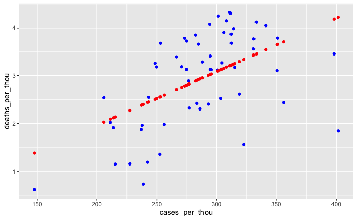

```r
US_tot_w_pred %>% ggplot() +
  geom_point(aes(x = cases_per_thou, y = deaths_per_thou), color = "blue") +
  geom_point(aes(x = cases_per_thou, y = pred), color = "red")
```

## Discussion on Bias

There is nothing as wonderful as being able to have so much data in one sheet. The upstream work that goes into providing this data is a rather big undertaking that we really don’t comprehend. However there are still many ways bias’ can get into the data.

### Data accuracy based on technology

There are going to be varying levels of accuracy of the data between countries and states across the world. Technology is a wonderful thing, it helps us coordinate to have this information but there are still many places even in the United States that are hand counting this information and using paper documentation and not EMR systems.

### Data accuracy based on nefarious reporting

There are also rumours that COVID cases might be high due to the payout a hospital receives from an insurance company. It would not surprise me that there will be a hand full of cases across the countless of hospitals and emergency care facilities that serve 330 million people. (just to rant… insurance companies will quickly get onto figure this out… they aren’t in the market for losing money).

### Early symptoms were confusing

In the early days, it could be said that PCR primer production has to be ramped up for all hospitals to be able to do PCR tests for COVID-19.

## Discussion / Conclusion

To conclude this analysis, we find that looking at the rate of cases / 1000 can tell alot of interesting stories about the data that we are looking at. We looked at NY and TN to give us some insight and an avenue to explore possible reasons for these differences. This could provide a rather lengthy project to further analyze the differences in the data and coming up with asystematic analysis to evaluate government decisions made at a local level to better understand their effectiveness.